# Real Estate Valuation

The real estate data were collected in Sindian District, New Taipei City, Taiwan in an attempt to measure how certain variables affect real estate prices.

#### Attributes

**Features**

*dbl* `transaction_date`: the date of the transaction  
*dbl* `age`: the age of the real estate  
*dbl* `distance_to_train_station`: the distance from the real estate to the nearest train station  
*int* `convenience_stores`: the number of convenience stores around the real estate within a constant radius  
*dbl* `latitude`: the latitude coordinate of the real estate  
*dbl* `longitude`: the longitude coordinate of the real estate

**Labels**

*dbl* `price`: the purchase price of the real estate

### Loading the data set

Use `setwd()` to set the current directory to the folder. Then load the data set by running the code below.

```r
houses <- read.csv('real_estate_valuation.csv', fileEncoding="UTF-8-BOM")
head(houses)
```

|  | transaction_date | age | distance_to_train_station | convenience_stores | latitude | longitude | price |
| --- | --- | --- | --- | --- | --- | --- | --- |
| 1 | 2012.917 | 32.0 | 84.87882 | 10 | 24.98298 | 121.5402 | 37.9 |
| 2 | 2012.917 | 19.5 | 306.59470 | 9 | 24.98034 | 121.5395 | 42.2 |
| 3 | 2013.583 | 13.3 | 561.98450 | 5 | 24.98746 | 121.5439 | 47.3 |
| 4 | 2013.500 | 13.3 | 561.98450 | 5 | 24.98746 | 121.5439 | 54.8 |
| 5 | 2012.833 | 5.0 | 390.56840 | 5 | 24.97937 | 121.5425 | 43.1 |
| 6 | 2012.667 | 7.1 | 2175.03000 | 3 | 24.96305 | 121.5125 | 32.1 |

### Plotting the data

Notice that the variables `distance_to_nearest_train_station`, `latitude`, and `longitude` show nonlinearity when plotted against `price`.

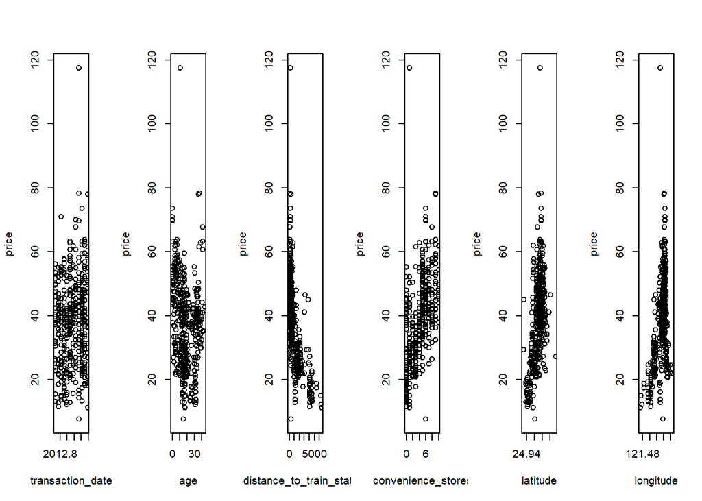

```r
par(mfrow = c(1, 6))
plot(price ~ transaction_date, houses)
plot(price ~ age, houses)
plot(price ~ distance_to_train_station, houses)
plot(price ~ convenience_stores, houses)
plot(price ~ latitude, houses)
plot(price ~ longitude, houses)
```

### Model selection

All variables are plugged in to the regression model. Since some variables exhibit nonlinearity, a quadratic term for each variable will be added to the model.

```r
model = lm(
  price ~
    transaction_date + I(transaction_date ^ 2) +
    age + I(age ^ 2) +
    distance_to_train_station + I(distance_to_train_station ^ 2) +
    convenience_stores + I(convenience_stores ^ 2) +
    latitude + I(latitude ^ 2) +
    longitude + I(longitude ^ 2),
  houses
)
summary(model)
```

```
##
## Call:
## lm(formula = price ~ transaction_date + I(transaction_date^2) +
##     age + I(age^2) + distance_to_train_station + I(distance_to_train_station^2) +
##     convenience_stores + I(convenience_stores^2) + latitude +
##     I(latitude^2) + longitude + I(longitude^2), data = houses)
##
## Residuals:
##     Min      1Q  Median      3Q     Max
## -33.480  -4.310  -0.282   3.653  72.830
##
## Coefficients: (2 not defined because of singularities)
##                                  Estimate Std. Error t value Pr(>|t|)
## (Intercept)                     3.847e+06  1.447e+06   2.658  0.00818 **
## transaction_date                6.022e+00  1.401e+00   4.297 2.17e-05 ***
## I(transaction_date^2)                  NA         NA      NA       NA
## age                            -1.022e+00  1.357e-01  -7.536 3.23e-13 ***
## I(age^2)                        1.866e-02  3.307e-03   5.642 3.17e-08 ***
## distance_to_train_station      -1.194e-02  1.268e-03  -9.419  < 2e-16 ***
## I(distance_to_train_station^2)  1.475e-06  2.138e-07   6.899 2.04e-11 ***
## convenience_stores              5.392e-01  5.006e-01   1.077  0.28209
## I(convenience_stores^2)         8.308e-03  5.180e-02   0.160  0.87267
## latitude                       -3.093e+05  1.158e+05  -2.670  0.00789 **
## I(latitude^2)                   6.198e+03  2.319e+03   2.672  0.00784 **
## longitude                      -5.758e+00  4.537e+01  -0.127  0.89906
## I(longitude^2)                         NA         NA      NA       NA
## ---
## Signif. codes:  0 '***' 0.001 '**' 0.01 '*' 0.05 '.' 0.1 ' ' 1
##
## Residual standard error: 7.95 on 403 degrees of freedom
## Multiple R-squared:  0.6668, Adjusted R-squared:  0.6586
## F-statistic: 80.66 on 10 and 403 DF,  p-value: < 2.2e-16
```

The quadratic terms of variables `transaction_date`, `convenience_stores`, and `longitude` will be eliminated from the model due to either large p-values or singularity.

```r
model = lm(
  price ~
    transaction_date +
    age + I(age ^ 2) +
    distance_to_train_station + I(distance_to_train_station ^ 2) +
    convenience_stores +
    latitude + I(latitude ^ 2) +
    longitude,
  houses
)
summary(model)
```

```
##
## Call:
## lm(formula = price ~ transaction_date + age + I(age^2) + distance_to_train_station +
##     I(distance_to_train_station^2) + convenience_stores + latitude +
##     I(latitude^2) + longitude, data = houses)
##
## Residuals:
##     Min      1Q  Median      3Q     Max
## -33.524  -4.323  -0.307   3.678  72.884
##
## Coefficients:
##                                  Estimate Std. Error t value Pr(>|t|)
## (Intercept)                     3.906e+06  1.399e+06   2.792 0.005488 **
## transaction_date                6.018e+00  1.400e+00   4.300 2.15e-05 ***
## age                            -1.024e+00  1.353e-01  -7.564 2.66e-13 ***
## I(age^2)                        1.870e-02  3.292e-03   5.680 2.58e-08 ***
## distance_to_train_station      -1.195e-02  1.264e-03  -9.456  < 2e-16 ***
## I(distance_to_train_station^2)  1.479e-06  2.118e-07   6.985 1.18e-11 ***
## convenience_stores              6.141e-01  1.809e-01   3.394 0.000756 ***
## latitude                       -3.140e+05  1.119e+05  -2.805 0.005273 **
## I(latitude^2)                   6.292e+03  2.241e+03   2.807 0.005238 **
## longitude                      -5.022e+00  4.508e+01  -0.111 0.911356
## ---
## Signif. codes:  0 '***' 0.001 '**' 0.01 '*' 0.05 '.' 0.1 ' ' 1
##
## Residual standard error: 7.941 on 404 degrees of freedom
## Multiple R-squared:  0.6668, Adjusted R-squared:  0.6594
## F-statistic: 89.84 on 9 and 404 DF,  p-value: < 2.2e-16
```

`longitude` is insignificant to the model so it will be removed from the model as well.

```r
model = lm(
  price ~
    transaction_date +
    distance_to_train_station + I(distance_to_train_station ^ 2) +
    age + I(age ^ 2) +
    convenience_stores +
    latitude + I(latitude ^ 2),
  houses
)
summary(model)
```

```
##
## Call:
## lm(formula = price ~ transaction_date + distance_to_train_station +
##     I(distance_to_train_station^2) + age + I(age^2) + convenience_stores +
##     latitude + I(latitude^2), data = houses)
##
## Residuals:
##     Min      1Q  Median      3Q     Max
## -33.508  -4.307  -0.335   3.689  72.938
##
## Coefficients:
##                                  Estimate Std. Error t value Pr(>|t|)
## (Intercept)                     3.867e+06  1.354e+06   2.855  0.00452 **
## transaction_date                6.015e+00  1.398e+00   4.304 2.11e-05 ***
## distance_to_train_station      -1.190e-02  1.177e-03 -10.116  < 2e-16 ***
## I(distance_to_train_station^2)  1.481e-06  2.106e-07   7.032 8.71e-12 ***
## age                            -1.024e+00  1.352e-01  -7.574 2.48e-13 ***
## I(age^2)                        1.870e-02  3.288e-03   5.688 2.46e-08 ***
## convenience_stores              6.144e-01  1.807e-01   3.400  0.00074 ***
## latitude                       -3.110e+05  1.085e+05  -2.867  0.00437 **
## I(latitude^2)                   6.231e+03  2.172e+03   2.869  0.00434 **
## ---
## Signif. codes:  0 '***' 0.001 '**' 0.01 '*' 0.05 '.' 0.1 ' ' 1
##
## Residual standard error: 7.931 on 405 degrees of freedom
## Multiple R-squared:  0.6668, Adjusted R-squared:  0.6602
## F-statistic: 101.3 on 8 and 405 DF,  p-value: < 2.2e-16
```

Now all the remaining variables are significant. No more variable needs to be removed from the model.

#### Code authorship

2021 © Jessan Rendell G. Belenzo

#### Terms of use

Licensed under the GNU General Public License v3.0. See LICENSE.

#### Data set

Yeh, I. C., & Hsu, T. K. (2018). *Building real estate valuation models with comparative approach through case-based reasoning*. Applied Soft Computing, 65, 260-271.  
Dua, D. and Graff, C. (2019). [*UCI Machine Learning Repository*](http://archive.ics.uci.edu/ml). Irvine, CA: University of California, School of Information and Computer Science.